# Aula Coda - parte 2

Manoel

11 de novembro de 2018

## Analisandos dados - replicando Br em dados

Eu sou um dos integrantes do grupo Brasil em dados, que durante as eleições fez uma série de gráficos sobre o país. Vamos aqui replicar alguns deles, para vocês terem uma ideia de como esse tipo de análise é feita.

Na url: https://github.com/brdados/graficos temos todos os gráficos feitos pelo Br em dados. Não dá para fazer tudo, até pela complexidade de alguns, mas podemos brincar com os mais fáceis.

Um doos gráficos mais compartilhados foi o do salário mínimo. Vamos replicar ele? Acessem https://github.com/brdados/graficos/blob/master/Grafico_salario_minimo.R Lá tem o script final para o gráfico. Como iremos devagar, sigam o scritp da aula.

## GRAFICO SALARIO MÍNIMO

Vamos carregar algumas bibliotecas (instalem se vocês não tiverem ela instaladas)

```r
library(ggplot2)
library(data.table)
library(dplyr)
library(tidyr)
library(scales)
```

Em vez de usarmos theme_bw(), por exemplo, usaremos tema_br_dados()

Os dados de salário mínimo são do IPEA (https://goo.gl/96BZwC) Eu baixei os dados, e deu um problema quando fui importar. Então abri no excel, salvei, e agora funciona a importação. Baixem do meu github, em: https://github.com/mgaldino/curso_coda/blob/master/ipea_salario_minimo.csv

[output not shown]

Vamos processar os dados?

```r
# filtrando os anos e meses que queremos
# transformando SM que está em formato de texto, para número
dados.df <- dados.df %>%
  filter(ANO %in% (1958:2018), MES== 9) %>%
  mutate(SMR = gsub(",", ".", VALVALOR),
         SMR = as.numeric(SMR))
```

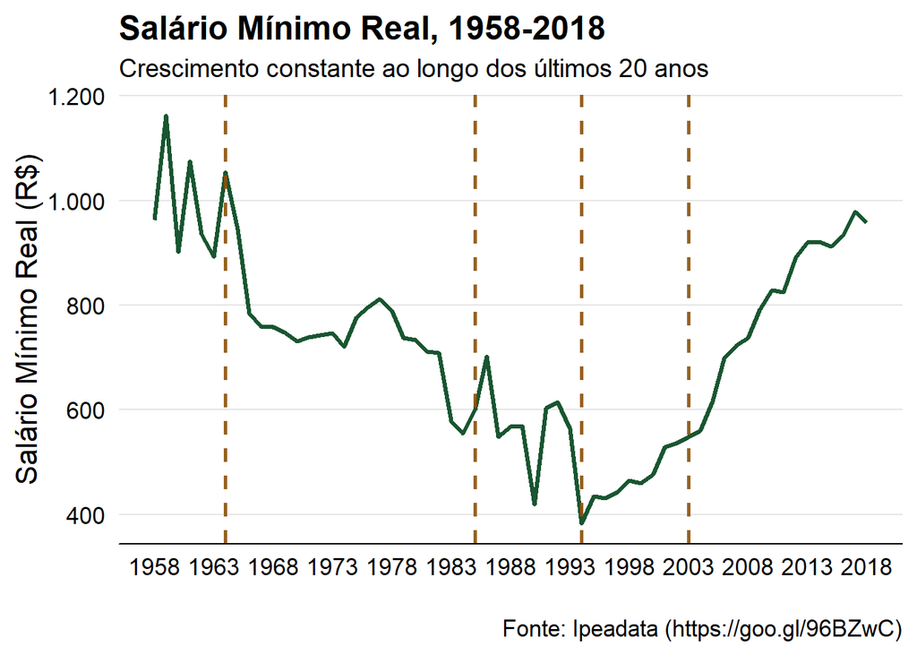

```r
# plotando o gráfico
p <- ggplot(dados.df, aes(x=ANO, y=SMR)) +
  geom_line(size=1.1, alpha=0.9, colour="#00441b") +
  geom_vline(xintercept=1964, size=0.98, colour="#8c510a",
             alpha=0.9, linetype="dashed") +
  geom_vline(xintercept=1985, size=0.98, colour="#8c510a",
             alpha=0.9, linetype="dashed") +
  geom_vline(xintercept=1994, size=0.98, colour="#8c510a",
             alpha=0.9, linetype="dashed") +
  geom_vline(xintercept=2003, size=0.98, colour="#8c510a",
             alpha=0.9, linetype="dashed") +
  tema_br_dados() +
  scale_x_continuous(breaks = seq(1958, 2018, by = 5)) +
  scale_y_continuous(labels=function(x) format(x, big.mark = ".", decimal.mark = ",", scientific = FALSE)) +
  labs(color = NULL, x = NULL, y = "Salário Mínimo Real (R$)",
       caption = "\nFonte: Ipeadata (https://goo.gl/96BZwC)",
       title = "Salário Mínimo Real, 1958-2018",
       subtitle = "Crescimento constante ao longo dos últimos 20 anos")

p
```

Agora, salvando o gráfico

```r
### Exportando para formato .png
ggsave(p, file= "plot_smr.png", dpi=300, width=6.89, height=4.88)
```

## Exercícios

Vamos acessar agora outros gráficos do Br em Dados, e tentar replicar. Vamos ler o código primeiro, e entender o que estásendo feito E então vamos replicar. Dica: Para instalar o pacote ipeaData, vamos usar o pacote devtools. Ele permite instalar um pacote direto do github. Nesse caso, o pacote ipeaData não está disponível para o R 3.5.0

```r
# library(devtools)
# install_github("ipea/ipeaData")
library(ipeaData)
? ipeadata
```

1. Anos de estudo https://github.com/brdados/graficos/blob/master/anos_estudo.R
2. ÁguaPotável: https://github.com/brdados/graficos/blob/master/agua_potavel.R
3. Defasagem escolar: https://github.com/brdados/graficos/blob/master/defasagem_escolar.R